# P8105_HW1_rs4788

Ruhui Shen

2025-09-19

```r
library("moderndive")
library(tidyverse)
```

# Problem 1

```r
data("early_january_weather")
```

## Description of the dataset:

The dataset contains meteorological data for the first half of January 2013. Key variables in this dataset include: Time indicators: year, month, day, hour,time_hour; Meteorological measurements: temp, dewp, humid, wind_dir, wind_speed, wind_gust, precip, pressure, visib. The mean temperature recorded in this period was 40°F, with humidity averaging 65%.

The size of the dataset is 358 rows and 15 columns.

The mean temperature is 39.5821229℉.

## Make a scatterplot:

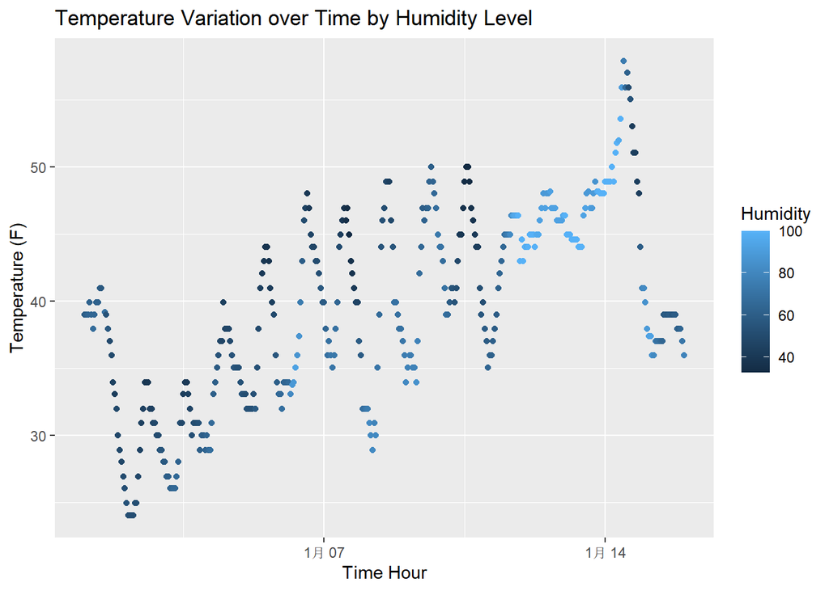

```r
library(ggplot2)
scatter_plot <- ggplot(early_january_weather,
                       aes(x = time_hour, y = temp, color = humid))+
            geom_point()+
              labs(title = "Temperature Variation over Time by Humidity Level",
               x = "Time Hour", y = "Temperature (F)",color = "Humidity")
print(scatter_plot)
```

```r
ggsave("temperature_vs_time_scatterplot.png", plot = scatter_plot,
       width = 10, height = 6)
```

# Problem 2

## Create a data frame:

```r
sample <- rnorm(10)
df <- data.frame(
  normal_sample = sample,
  logical_vector = sample > 0,
  character_vector = c("S","A","M","A","N","T","H","A","H","W"),
  factor_vector = factor(rep(c("Low", "Medium", "High"), length.out = 10)) )

str(df)
```

```
## 'data.frame':    10 obs. of  4 variables:
##  $ normal_sample   : num  -1.4758 -0.2797 -0.1232 0.376 -0.0595 ...
##  $ logical_vector  : logi  FALSE FALSE FALSE TRUE FALSE FALSE ...
##  $ character_vector: chr  "S" "A" "M" "A" ...
##  $ factor_vector   : Factor w/ 3 levels "High","Low","Medium": 2 3 1 2 3 1 2 3 1 2
```

## Take the mean of each variable:

```r
mean(pull(df, normal_sample))
```

```
## [1] -0.1601801
```

```r
mean(pull(df, logical_vector))
```

```
## [1] 0.4
```

```r
mean(pull(df, character_vector))
```

```
## [1] NA
```

```r
mean(pull(df, factor_vector))
```

```
## [1] NA
```

Works: Numeric variables and logical variables. Doesn’t Work: Character variables and factor variables.

## Convert variables:

```r
logical_numeric <- as.numeric(df$logical_vector)
character_numeric <- as.numeric(df$character_vector)
factor_numeric <- as.numeric(df$factor_vector)
```

For logical variables, `as.numeric` converts TRUE and FALSE to 1 and 0, yielding a numeric vector that enables mean calculation.

For character variables, `as.numeric` attempts to convert characters to numeric values. However, since characters are not numeric, all elements become NA, explaining why calculating the mean of a character vector fails.